# The Future Economics of LLMs — a numerical illustration

This notebook puts numbers on the model in *"The Future Economics of LLMs: From Hyperscaler GPUs to Consumer Usage"* (Manheim, 2026). The paper is deliberately abstract: it states an allocation rule (`v_m = c + λ`), a three-component price decomposition, a temporary-leadership value formula, and a taxonomy of long-run technological regimes, but leaves the demand system `R(y;Q)` and `D_m(P,Q)` as general primitives and never puts a single number on the page.

The point of this notebook is to commit to the simplest concrete demand system consistent with the paper's Section *"Purchasers, Models, and Compute Requirements"*, run it through the paper's own closed forms, and produce four figures:

1. **Allocation vs. capacity** — the water-filling allocation from the integrated-industry benchmark, and the shadow price `λ`, as aggregate capacity `K` varies.
2. **Price decomposition** — the three-component price (physical cost / hyperscaler scarcity rent / model-provider markup) from the symmetric Cournot example, showing that the consumer price is independent of the number of labs when capacity binds, while the *split* is not.
3. **Rent shares over a release cycle** — a seeded simulation of the lumpy-release dynamics, showing surplus shifting toward labs after a breakthrough and toward hyperscalers during catch-up.
4. **The three technological regimes** — quality gap, markup, and scarcity rent over a long horizon under a common asymptote, firm-specific asymptotes, and continuing improvement.

A note on reuse: the formulas are written as small pure functions with explicit parameters, because a later web-demo project may port them to TypeScript. Keep them side-effect free.

## Parameters and why these values

The paper pins down almost nothing numerically, so we adopt the normalized parameterization already floated for the companion web demo (and recommended in the paper review's numerical- illustration item). It is chosen for legibility, not realism — the goal is to see the mechanisms, not to estimate anything.

| Symbol | Value | Meaning / rationale |
| --- | --- | --- |
| `c` | 1.0 | physical operating cost per FLOP — the numeraire; everything is priced relative to it |
| `q_L` | 1.4 | leader quality-adjusted productivity per FLOP (`Q/a`); a 40% frontier edge |
| `q_FA` | 1.1 | Follower A productivity; a near-frontier lab |
| `q_FB` | 0.9 | Follower B productivity; a trailing lab, below the leader in raw `q` |
| `a` | 1.0 | FLOPs per standardized output, same for all firms (so `Q_m = q_m` here) |
| `b` | 0.0 | other variable cost per output; set to zero to keep the decomposition clean |
| `K` | 100.0 | aggregate short-run capacity (FLOPs/period); the scarce input |
| `N` | 300.0 | mass of purchasers |
| `θ_max` | 10.0 | willingness-to-pay upper bound; `θ ~ Uniform[0, θ_max]` |

Generic firm names ("Leader", "Follower A", "Follower B") are used deliberately — real company names would invite arguments about calibration instead of the mechanism.

**Choice flagged:** `a = 1` and `b = 0` for all firms. With `a` common across firms, the productivity ranking in `q` is also the ranking in total quality `Q`, which keeps the pictures readable. The paper's `a_m` and `b_m` machinery (and its output-unit-invariance result, Appendix E.2) still applies; we just don't exercise the heterogeneity here.

```python
import numpy as np
import matplotlib.pyplot as plt
from matplotlib.ticker import MaxNLocator
from pathlib import Path

FIGDIR = Path("figures")
FIGDIR.mkdir(exist_ok=True)

# --- publication-quality matplotlib defaults ---
plt.rcParams.update({
    "figure.dpi": 120,
    "savefig.dpi": 200,
    "savefig.bbox": "tight",
    "font.size": 11,
    "axes.titlesize": 12,
    "axes.labelsize": 11,
    "axes.spines.top": False,
    "axes.spines.right": False,
    "axes.grid": True,
    "grid.color": "#e1e0d9",
    "grid.linewidth": 0.8,
    "axes.axisbelow": True,
    "axes.edgecolor": "#c3c2b7",
    "legend.frameon": False,
    "figure.facecolor": "white",
    "axes.facecolor": "white",
})

# --- palette (validated categorical hues; see dataviz skill) ---
C_LEADER = "#2a78d6"   # blue
C_FA     = "#eb6834"   # orange
C_FB     = "#1baf7a"   # aqua
FIRM_COLORS = {"Leader": C_LEADER, "Follower A": C_FA, "Follower B": C_FB}

# price-component / rent-split colors: physical cost neutral, hyperscaler red, lab blue
C_PHYS = "#898781"     # physical production cost (neutral baseline, meant to recede)
C_SCAR = "#e34948"     # hyperscaler scarcity rent
C_MARK = "#2a78d6"     # model-provider (lab) markup
C_LAB  = "#2a78d6"     # labs, in rent-share charts
C_HYP  = "#e34948"     # hyperscalers, in rent-share charts

INK = "#0b0b0b"; MUTED = "#52514e"

# --- baseline parameters ---
c        = 1.0
K        = 100.0
N        = 300.0
theta_max = 10.0
b        = 0.0
a        = 1.0
q_L, q_FA, q_FB = 1.4, 1.1, 0.9
print("Baseline set. c=%.1f  K=%.0f  N=%.0f  theta_max=%.0f  q=(%.1f, %.1f, %.1f)"
      % (c, K, N, theta_max, q_L, q_FA, q_FB))
```

```
Baseline set. c=1.0  K=100  N=300  theta_max=10  q=(1.4, 1.1, 0.9)
```

## 1. The integrated-industry allocation benchmark

This section implements the paper's *"Integrated-Industry Allocation Benchmark"* — the boxed condition `v_m = c + λ` (paper eq. after "The allocation condition becomes"). The benchmark allocates scarce compute across models to maximize joint operating profit, and every active model ends up with the same marginal net revenue per FLOP, equal to physical cost plus the capacity shadow price.

### The concrete demand system (a concretization the paper does not derive)

The paper defines purchaser utility `u_im = θ_i·Q_m − P_m` with `θ ~ F` (Section *"Purchasers, Models, and Compute Requirements"*) but leaves `R(y;Q)` and `D_m(P,Q)` abstract. To produce numbers we must commit to a demand system. Following the review's suggestion (paper-review- notes.md §1.1.3 and §4.1) and the single-model formula the paper *does* give (Section *"Prices and the Division of Rents"*, `D_L(P_L)=N[1−F(P_L/Q_L)]`, leading to `P_L^* = Q_L·F^{-1}(1 − K/(a_L·N))`), we take:

- `θ ~ Uniform[0, θ_max]`, so `F(z) = z/θ_max` and `F^{-1}(u) = u·θ_max`;
- purchasers of mass `N`;
- **and — the part the paper leaves open — we treat each model's demand as a residual against the full purchaser distribution**, i.e. model `m` sold at quantity `y_m` faces inverse demand `P_m(y_m) = Q_m·θ_max·(1 − y_m/N)`, which is exactly the single-model formula above, inverted.

From this, marginal revenue is `MR_m = Q_m·θ_max·(1 − 2y_m/N)` and marginal net revenue per FLOP is

`v_m(x_m) = (MR_m − b_m)/a_m = q_m·θ_max·(1 − 2·x_m/(a_m·N)) − b_m/a_m`,

a downward-sloping schedule with intercept `v_m(0) = q_m·θ_max − b_m/a_m` that is increasing in productivity `q_m` — which is the paper's assumption `∂v_m/∂q_m > 0` (Section *"Persistent Laboratory Productivity"*) made concrete rather than assumed.

```python
def v_schedule(x, q, a=a, b=b, theta_max=theta_max, N=N):
    '''Marginal net revenue per FLOP for a model of productivity q, given compute x.

    v_m(x) = q*theta_max*(1 - 2 x/(a N)) - b/a   (paper: v_m = (MR_m - b_m)/a_m,
    with the residual single-model demand P_m(y)=Q_m*theta_max*(1 - y/N)).
    Returns a plain float/array; not clipped (can go negative past the choke point).'''
    return q * theta_max * (1.0 - 2.0 * x / (a * N)) - b / a


def allocate(K, qs, a=a, b=b, c=c, theta_max=theta_max, N=N):
    '''Water-filling allocation of the integrated benchmark.

    Solves  v_m(x_m) = c + lam  for every active model, with sum_m a*x_m... (a=1 here so
    sum x_m) <= K and x_m >= 0. Returns (x_array, lam). If capacity is slack, lam = 0 and
    each model sits at its unconstrained joint-profit output (v_m = c).'''
    qs = np.atleast_1d(np.asarray(qs, dtype=float))

    def x_of_lam(lam):
        # invert v_m(x) = c + lam  ->  x = (a N / 2)(1 - (c+lam+b/a)/(q theta_max))
        x = (a * N / 2.0) * (1.0 - (c + lam + b / a) / (qs * theta_max))
        return np.clip(x, 0.0, None)

    if x_of_lam(0.0).sum() <= K:          # capacity slack
        return x_of_lam(0.0), 0.0
    lo, hi = 0.0, float(qs.max() * theta_max)   # lam high enough that all x = 0
    for _ in range(200):                  # bisection on the shadow price
        mid = 0.5 * (lo + hi)
        if x_of_lam(mid).sum() > K:
            lo = mid
        else:
            hi = mid
    lam = 0.5 * (lo + hi)
    return x_of_lam(lam), lam


# sanity check at the baseline
_x, _lam = allocate(K, [q_L, q_FA, q_FB])
print("At K=%.0f: allocation = %s (sum=%.1f), lambda = %.3f, wholesale c+lam = %.3f"
      % (K, np.round(_x, 1), _x.sum(), _lam, c + _lam))
print("Active models (x>0):", [n for n, xx in zip(["Leader","Follower A","Follower B"], _x) if xx > 1e-6])
```

```
At K=100: allocation = [58.6 33.6  7.8] (sum=100.0), lambda = 7.533, wholesale c+lam = 8.533
Active models (x>0): ['Leader', 'Follower A', 'Follower B']
```

### Figure 1 — Allocation and the shadow price as capacity varies

The top panel shows the water-filling allocation: how the `K` available FLOPs are split across the three firms as aggregate capacity grows from very scarce to abundant. The bottom panel is the capacity shadow price `λ` (the scarcity rent per FLOP), which is what the benchmark's `v_m = c + λ` condition prices the marginal FLOP at, net of physical cost `c`.

Read it left to right. When capacity is very tight only the leader is active (its marginal FLOP still outbids every follower's first FLOP — the paper's winner-take-all condition `v_L(K) ≥ max_j v_j(0)` holds). As `K` grows, `λ` falls; once `c + λ` drops below a follower's intercept `q·θ_max`, that follower switches on and starts receiving compute — first Follower A, then Follower B. Past the point where `λ` hits zero, capacity is slack: the marginal FLOP is worth only physical cost and there is no scarcity rent. Two axes, two stacked panels sharing the capacity axis (deliberately not one dual-axis chart).

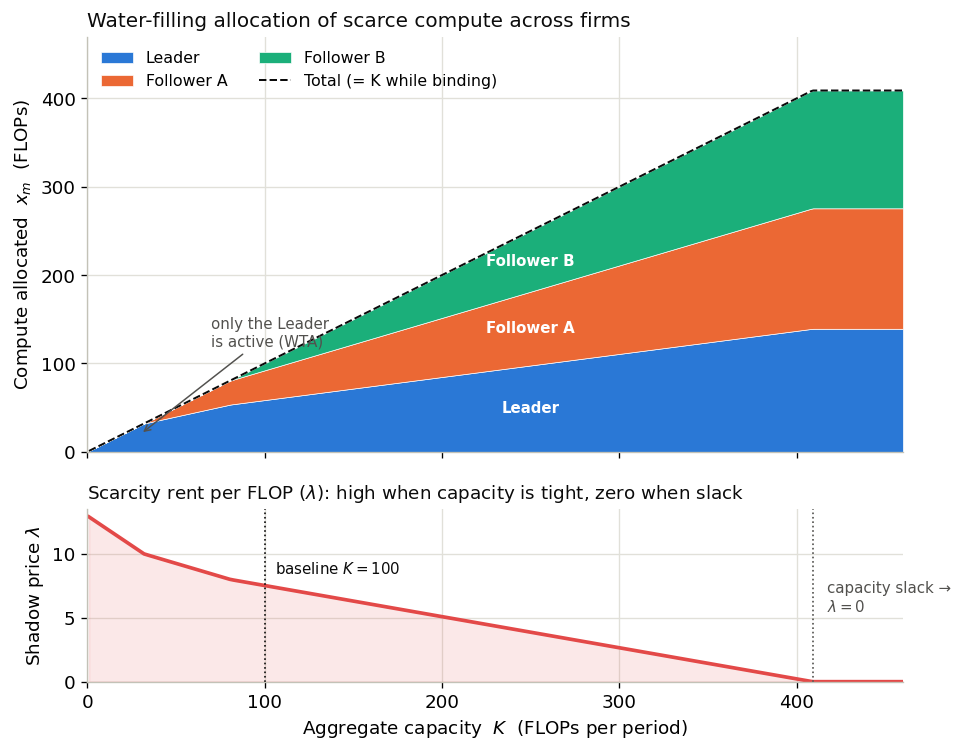

```
saved fig1_allocation_vs_K.png; capacity goes slack near K = 409
```

```python
Ks = np.linspace(1, 460, 400)
qs = np.array([q_L, q_FA, q_FB])
names = ["Leader", "Follower A", "Follower B"]
alloc = np.array([allocate(k, qs)[0] for k in Ks])   # shape (len Ks, 3)
lams  = np.array([allocate(k, qs)[1] for k in Ks])

fig, (ax1, ax2) = plt.subplots(2, 1, figsize=(8.2, 6.4), sharex=True,
                               gridspec_kw={"height_ratios": [2.4, 1]})

# top: stacked allocation
ax1.stackplot(Ks, alloc[:, 0], alloc[:, 1], alloc[:, 2],
              colors=[C_LEADER, C_FA, C_FB], labels=names, edgecolor="white", linewidth=0.4)
ax1.plot(Ks, alloc.sum(axis=1), color=INK, lw=1.2, ls="--", label="Total (= K while binding)")
ax1.set_ylabel("Compute allocated  $x_m$  (FLOPs)")
ax1.set_title("Water-filling allocation of scarce compute across firms", loc="left", color=INK)
ax1.set_ylim(0, 470)
ax1.legend(loc="upper left", ncol=2, fontsize=9.5)
# direct labels on the stacked bands at a representative K
kx = 250
ci = np.searchsorted(Ks, kx)
yc = np.cumsum(alloc[ci]) - alloc[ci] / 2
for j, nm in enumerate(names):
    if alloc[ci, j] > 8:
        ax1.text(kx, yc[j], nm, ha="center", va="center", color="white", fontsize=9, fontweight="bold")

# annotate the regime where only the leader is active
ax1.annotate("only the Leader\nis active (WTA)", xy=(30, 20), xytext=(70, 120),
             fontsize=9, color=MUTED, ha="left",
             arrowprops=dict(arrowstyle="->", color=MUTED, lw=0.9))

# bottom: shadow price
ax2.plot(Ks, lams, color=C_SCAR, lw=2.2)
ax2.fill_between(Ks, lams, color=C_SCAR, alpha=0.12)
ax2.set_ylabel(r"Shadow price $\lambda$")
ax2.set_xlabel("Aggregate capacity  $K$  (FLOPs per period)")
ax2.set_title(r"Scarcity rent per FLOP ($\lambda$): high when capacity is tight, zero when slack",
              loc="left", color=INK, fontsize=11)
ax2.set_xlim(0, 460); ax2.set_ylim(0, None)
# mark where capacity goes slack
k_slack = Ks[np.argmax(lams <= 1e-6)]
ax2.axvline(k_slack, color=MUTED, ls=":", lw=1)
ax2.annotate("capacity slack →\n$\\lambda=0$", xy=(k_slack, 2), xytext=(k_slack + 8, 5.5),
             fontsize=9, color=MUTED)
ax2.axvline(K, color=INK, ls=":", lw=1)
ax2.annotate("baseline $K=100$", xy=(K, lams[np.searchsorted(Ks, K)]), xytext=(K + 6, 8.5),
             fontsize=9, color=INK)

fig.tight_layout()
fig.savefig(FIGDIR / "fig1_allocation_vs_K.png")
plt.show()
print("saved fig1_allocation_vs_K.png; capacity goes slack near K =", round(float(k_slack)))
```

## 2. The symmetric Cournot example (price decomposition)

This section implements the paper's Appendix *"A Symmetric Cournot Example"* directly — the closed forms are given, so there is nothing to invent here. `n` symmetric labs sell a homogeneous inference service with linear inverse demand `P(Y) = A − B·Y`. Each output needs `a` FLOPs and has non-compute cost `b`; given wholesale compute price `r`, marginal cost is `κ = b + a·r`.

**Mapping the linear demand to our numbers (a choice).** The Cournot appendix is self-contained and homogeneous, so we map it to a single representative frontier quality: `A = q̄·θ_max` and `B = A/N`, matching the single-model inverse demand at quality `q̄`. We use `q̄ = q_L = 1.4`, i.e. we imagine `n` symmetric frontier labs. This is the natural bridge (documented in the web- demo plan) and is flagged as a choice: a different `q̄` shifts the intercept but not the qualitative story.

The paper's closed forms, with binding capacity `a·Y = K`:

- consumer price `P* = A − B·K/a` — **independent of `n`**;
- wholesale compute price `r* = (A−b)/a − B(n+1)K/(a²·n)`;
- per-firm markup `P* − κ = B·K/(a·n)`;
- aggregate lab profit `Π = B·K²/(a²·n)`;
- binding threshold: capacity binds iff `K < a·n·(A−b−a·c)/(B·(n+1))`.

And the boxed three-component decomposition (paper Section *"Oligopolistic Model Provision"*): `P = (b + a·c) + a·(r − c) + μ` = physical cost + hyperscaler scarcity rent + model-provider markup.

```python
qbar = q_L                     # representative frontier quality for the homogeneous example
A = qbar * theta_max           # demand intercept
B = A / N                      # demand slope
print("Linear demand: A = %.3f, B = %.5f  (qbar = %.2f)" % (A, B, qbar))


def cournot_binding_threshold(n, A=A, B=B, a=a, b=b, c=c):
    '''Capacity binds (given r would fall to c) iff K < this.'''
    return a * n * (A - b - a * c) / (B * (n + 1))


def cournot_decomposition(n, K, A=A, B=B, a=a, b=b, c=c):
    '''Return the three price components (physical, scarcity, markup) and P, r for n labs.

    Uses the binding closed forms when capacity binds, else the slack (unconstrained Cournot)
    outcome with r*=c. All from the paper's Appendix 'A Symmetric Cournot Example'.'''
    Kthr = cournot_binding_threshold(n, A, B, a, b, c)
    physical = b + a * c
    if K < Kthr:                                   # capacity binds
        P = A - B * K / a
        r = (A - b) / a - B * (n + 1) * K / (a ** 2 * n)
        markup = B * K / (a * n)                   # = P - kappa
    else:                                          # capacity slack: r* = c
        r = c
        Y = n * (A - b - a * c) / (B * (n + 1))    # unconstrained Cournot output
        P = A - B * Y
        markup = P - (b + a * c)
    scarcity = a * (r - c)
    return dict(P=P, r=r, physical=physical, scarcity=scarcity, markup=markup, binding=(K < Kthr))


# quick check that components add up to P at the baseline
d = cournot_decomposition(3, K)
print("n=3, K=%.0f: P=%.3f  = phys %.3f + scarcity %.3f + markup %.3f  (binding=%s)"
      % (K, d["P"], d["physical"], d["scarcity"], d["markup"], d["binding"]))
assert abs(d["physical"] + d["scarcity"] + d["markup"] - d["P"]) < 1e-9
```

```
Linear demand: A = 14.000, B = 0.04667  (qbar = 1.40)
n=3, K=100: P=9.333  = phys 1.000 + scarcity 6.778 + markup 1.556  (binding=True)
```

### Figure 2 — The price decomposition, vs. number of labs and vs. capacity

Two panels, each a stacked bar of the three price components summing to the consumer price `P`.

**Left — vary the number of labs `n`, capacity binding (`K = 100`).** This is the paper's most quotable result: with capacity binding, the *total* consumer price is flat across `n` (the black markers), but the split moves. More labs compete away the model-provider markup (blue), and that surplus reappears as hyperscaler scarcity rent (red) because more labs bid the wholesale compute price up. Adding labs doesn't lower the price; it just changes who gets the money.

**Right — vary capacity `K`, at `n = 3`.** Here the total price *does* respond. While capacity binds, growing `K` lowers the price and shrinks the scarcity rent (red) toward zero. Past the binding threshold (dotted line) capacity is slack, the scarcity component vanishes, and only the physical cost and the ordinary Cournot markup remain. This is the "build GPUs to lower prices; add labs to redistribute rents" contrast the paper draws.

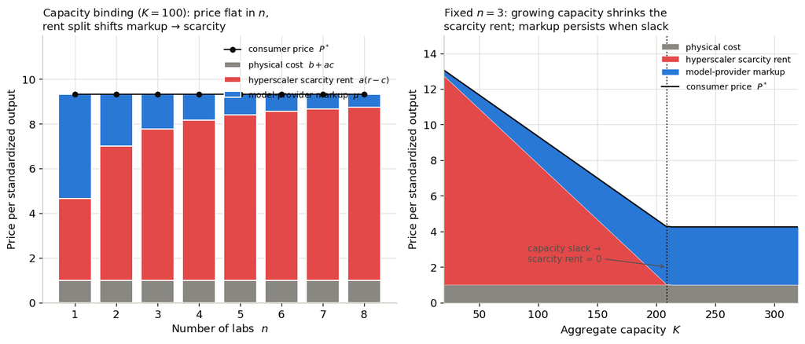

```
saved fig2_price_decomposition.png; binding threshold at n=3 is K = 208.9
Consumer price across n (should be constant): [9.333 9.333 9.333 9.333 9.333 9.333 9.333 9.333]
```

```python
fig, (axL, axR) = plt.subplots(1, 2, figsize=(11.5, 5.0))

# ---- Left: vs n, K=100 (binding) ----
ns = np.arange(1, 9)
phys = np.array([cournot_decomposition(n, K)["physical"] for n in ns])
scar = np.array([cournot_decomposition(n, K)["scarcity"] for n in ns])
mark = np.array([cournot_decomposition(n, K)["markup"] for n in ns])
Ptot = phys + scar + mark

axL.bar(ns, phys, color=C_PHYS, label="physical cost  $b+ac$", edgecolor="white", linewidth=1.2)
axL.bar(ns, scar, bottom=phys, color=C_SCAR, label="hyperscaler scarcity rent  $a(r-c)$",
        edgecolor="white", linewidth=1.2)
axL.bar(ns, mark, bottom=phys + scar, color=C_MARK, label="model-provider markup  $\\mu$",
        edgecolor="white", linewidth=1.2)
axL.plot(ns, Ptot, "o-", color=INK, lw=1.2, ms=5, label="consumer price  $P^*$")
axL.set_xlabel("Number of labs  $n$")
axL.set_ylabel("Price per standardized output")
axL.set_title("Capacity binding ($K=100$): price flat in $n$,\nrent split shifts markup → scarcity",
              loc="left", fontsize=11, color=INK)
axL.set_xticks(ns)
axL.legend(loc="upper right", fontsize=8.6)
axL.set_ylim(0, Ptot.max() * 1.28)

# ---- Right: vs K, n=3 ----
n_fixed = 3
Kgrid = np.linspace(20, 320, 60)
physK = np.array([cournot_decomposition(n_fixed, k)["physical"] for k in Kgrid])
scarK = np.array([cournot_decomposition(n_fixed, k)["scarcity"] for k in Kgrid])
markK = np.array([cournot_decomposition(n_fixed, k)["markup"] for k in Kgrid])
axR.stackplot(Kgrid, physK, scarK, markK, colors=[C_PHYS, C_SCAR, C_MARK],
              labels=["physical cost", "hyperscaler scarcity rent", "model-provider markup"],
              edgecolor="white", linewidth=0.3)
axR.plot(Kgrid, physK + scarK + markK, color=INK, lw=1.4, label="consumer price  $P^*$")
Kthr3 = cournot_binding_threshold(n_fixed)
axR.axvline(Kthr3, color=INK, ls=":", lw=1.2)
axR.annotate("capacity slack →\nscarcity rent = 0", xy=(Kthr3, 2.0), xytext=(Kthr3 - 118, 2.3),
             fontsize=9, color=MUTED, arrowprops=dict(arrowstyle="->", color=MUTED, lw=0.9))
axR.set_xlabel("Aggregate capacity  $K$")
axR.set_ylabel("Price per standardized output")
axR.set_title("Fixed $n=3$: growing capacity shrinks the\nscarcity rent; markup persists when slack",
              loc="left", fontsize=11, color=INK)
axR.legend(loc="upper right", fontsize=8.6)
axR.set_xlim(20, 320); axR.set_ylim(0, 15)

fig.tight_layout()
fig.savefig(FIGDIR / "fig2_price_decomposition.png")
plt.show()
print("saved fig2_price_decomposition.png; binding threshold at n=3 is K =", round(float(Kthr3), 1))
print("Consumer price across n (should be constant):", np.round(Ptot, 3))
```

## 3. A simulated release cycle and temporary leadership

This section builds a small seeded discrete-time simulation of the paper's Section *"Dynamic Model Development and Temporary Leadership"* — the lumpy release process, the productivity draw `log q^new = A_t + α_ℓ + ζ`, the compute-share partial-adjustment rule `s_{ℓ,t+1} = (1−σ)·s_{ℓt} + σ·ŝ_{ℓt}`, and the temporary-leadership value `V_lead ≈ Δπ/(r+Λ)`.

**Modeling choices the paper leaves open (flagged):**

- **Release hazard.** The paper writes the release probability as a general increasing function `h_ℓ(g_ℓt, I_ℓt)`. We do not model the compute/research inputs; we fix a constant per-period hazard per firm (`h`) and draw releases as independent Bernoulli events. This is the simplest thing consistent with "releases are lumpy and stochastic".
- **Persistent advantage.** `α_ℓ = log(η_ℓ)` with `η = (1.4, 1.1, 0.9)`, matching the baseline productivities, so the leader's *expected* draw is highest but any firm can jump on a good `ζ`. Deployed productivity is a ratchet: `q_{t+1} = max(q_t, q^new)` (paper's release rule).
- **The rent split.** The paper's dynamic claim is about the division between the leader's differential rent and the hyperscaler's scarcity rent. We compute it from the benchmark water-filling of Section 1: hyperscalers earn the shadow price on every FLOP, `H = λ·K`; total surplus above physical cost is the area under the marginal-value schedules,

**Caveat carried from the paper review (§1.5):** `Δπ` and the catch-up hazard `Λ` are not really independent — a bigger leadership prize attracts more challenger investment, raising `Λ`. Here they are set separately for illustration; treat `V_lead` as a partial-equilibrium snapshot.

```python
def surplus_split(qs, K=K, a=a, b=b, c=c, theta_max=theta_max, N=N):
    '''Given a productivity vector, return (lab_rent, hyperscaler_rent, total_surplus, lam, x).

    Hyperscaler rent = lam*K (scarcity rent per FLOP times capacity).
    Total surplus above physical cost = sum of area under each v-schedule above c.
    Lab rent = total - hyperscaler.'''
    qs = np.atleast_1d(np.asarray(qs, float))
    x, lam = allocate(K, qs, a, b, c, theta_max, N)
    # area under v_ell above c from 0..x_ell:  intercept0 = q*theta_max - b/a ; slope = 2 q theta_max/(aN)
    icpt = qs * theta_max - b / a
    slope = 2.0 * qs * theta_max / (a * N)
    area = (icpt - c) * x - 0.5 * slope * x ** 2      # integral of (v - c) dx
    S = float(np.sum(area))
    H = lam * K
    return S - H, H, S, lam, x


def simulate_releases(T=48, hazards=(0.10, 0.22, 0.22), etas=(1.4, 1.1, 0.9),
                      g=0.004, sigma_zeta=0.16, sigma_adj=0.4, q0_scale=1.0, seed=7):
    '''Seeded discrete-time release simulation. Returns a dict of time series.'''
    rng = np.random.default_rng(seed)
    names = ["Leader", "Follower A", "Follower B"]
    etas = np.array(etas, float); alpha = np.log(etas)
    qbar0 = q0_scale
    q = etas * qbar0                              # deployed productivity, starts at eta*qbar0
    s = np.array([allocate(K, q)[0]]); s = s[0] / max(s[0].sum(), 1e-9)   # initial compute shares
    hist = {k: [] for k in ["q", "shares", "lab_share", "hyp_share", "lam", "releases", "leader"]}
    for t in range(T):
        qbar_t = qbar0 * (1.0 + g) ** t
        rel = np.zeros(3, bool)
        for i in range(3):
            if rng.random() < hazards[i]:
                cand = np.exp(np.log(qbar_t) + alpha[i] + rng.normal(0, sigma_zeta))
                if cand > q[i]:
                    q[i] = cand; rel[i] = True
        # static equilibrium: target compute shares from benchmark allocation
        x_star, lam = allocate(K, q)
        s_hat = x_star / max(x_star.sum(), 1e-9)
        s = (1 - sigma_adj) * s + sigma_adj * s_hat        # partial adjustment (paper rule)
        lab, hyp, S, lam2, _ = surplus_split(q)
        hist["q"].append(q.copy())
        hist["shares"].append(s.copy())
        hist["lab_share"].append(lab / S if S > 0 else np.nan)
        hist["hyp_share"].append(hyp / S if S > 0 else np.nan)
        hist["lam"].append(lam2)
        hist["releases"].append(rel.copy())
        hist["leader"].append(int(np.argmax(q)))
    for k in hist: hist[k] = np.array(hist[k])
    hist["names"] = names
    return hist


sim = simulate_releases(hazards=(0.14, 0.24, 0.24), seed=14)
print("Simulated %d periods. Final deployed q = %s" % (len(sim["q"]), np.round(sim["q"][-1], 2)))
print("Lab surplus share range: %.2f – %.2f" % (np.nanmin(sim["lab_share"]), np.nanmax(sim["lab_share"])))
print("Release events per firm:", sim["releases"].sum(axis=0))
```

```
Simulated 48 periods. Final deployed q = [2.07 1.5  1.21]
Lab surplus share range: 0.18 – 0.25
Release events per firm: [5 4 3]
```

### Figure 3 — Rent shares over a release cycle

Three stacked panels sharing the time axis:

1. **Deployed productivity `q_ℓt`** as step functions. Releases ratchet a firm's quality up; markers flag the periods when a firm shipped a new model.
2. **Compute shares** (stacked areas), evolving with the partial-adjustment rule — shares move gradually toward the new static target after a release, not instantly.
3. **Division of producer surplus** between labs (blue) and hyperscalers (red). This is the panel that tests the paper's boxed claim: labs tend to capture a larger share right after a breakthrough that opens up a quality gap, and the hyperscaler share tends to rise as followers catch up and compress the gap.

Whether the numbers cooperate with the qualitative claim is discussed right after the figure.

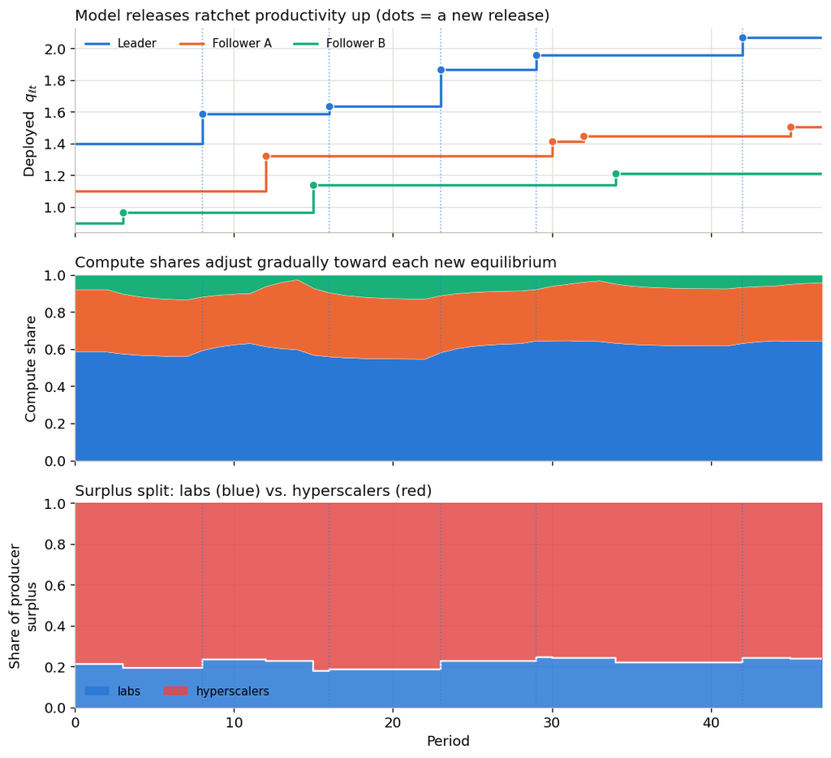

```
saved fig3_rent_shares_release_cycle.png
leader-release periods: [8, 16, 23, 29, 42]
```

```python
T = len(sim["q"]); ts = np.arange(T)
names = sim["names"]
fig, (a1, a2, a3) = plt.subplots(3, 1, figsize=(9.2, 8.4), sharex=True,
                                 gridspec_kw={"height_ratios": [1.1, 1.0, 1.1]})

# panel 1: quality step functions + release markers
for i, nm in enumerate(names):
    a1.step(ts, sim["q"][:, i], where="post", color=FIRM_COLORS[nm], lw=2, label=nm)
    rel_t = ts[sim["releases"][:, i]]
    a1.scatter(rel_t, sim["q"][sim["releases"][:, i], i], color=FIRM_COLORS[nm],
               s=42, zorder=5, edgecolor="white", linewidth=0.8)
a1.set_ylabel("Deployed  $q_{\\ell t}$")
a1.set_title("Model releases ratchet productivity up (dots = a new release)", loc="left", color=INK)
a1.legend(loc="upper left", ncol=3, fontsize=9)

# panel 2: compute shares (stacked)
a2.stackplot(ts, sim["shares"][:, 0], sim["shares"][:, 1], sim["shares"][:, 2],
             colors=[C_LEADER, C_FA, C_FB], labels=names, edgecolor="white", linewidth=0.2)
a2.set_ylabel("Compute share")
a2.set_ylim(0, 1)
a2.set_title("Compute shares adjust gradually toward each new equilibrium", loc="left", color=INK)

# panel 3: surplus split
a3.fill_between(ts, 0, sim["lab_share"], color=C_LAB, alpha=0.85, step="post", label="labs")
a3.fill_between(ts, sim["lab_share"], 1, color=C_HYP, alpha=0.85, step="post", label="hyperscalers")
a3.plot(ts, sim["lab_share"], color="white", lw=1.4, drawstyle="steps-post")
a3.set_ylabel("Share of producer\nsurplus")
a3.set_ylim(0, 1); a3.set_xlim(0, T - 1)
a3.set_xlabel("Period")
a3.set_title("Surplus split: labs (blue) vs. hyperscalers (red)", loc="left", color=INK)
a3.legend(loc="lower left", ncol=2, fontsize=9)

# mark leader-breakthrough periods (leader releases AND extends its lead) across panels
lead_breaks = [t for t in ts if sim["releases"][t, 0] and sim["leader"][t] == 0]
for t in lead_breaks:
    for ax in (a1, a2, a3):
        ax.axvline(t, color=C_LEADER, ls=":", lw=1.0, alpha=0.6)

fig.tight_layout()
fig.savefig(FIGDIR / "fig3_rent_shares_release_cycle.png")
plt.show()
print("saved fig3_rent_shares_release_cycle.png")
print("leader-release periods:", lead_breaks)
```

## 4. The three technological regimes

This section implements the three `q_ℓ(G)` functional forms from the paper's Section *"Technological Regimes, Consumer Prices, and Rent Shares"*, where `G` is cumulative effective training investment:

- **Common global asymptote:** `q_ℓ(G) = q̄ − d_ℓ·(ψ_ℓ·G)^{−β}` — every lab converges to the same ceiling `q̄`; `ψ_ℓ` is a research-*speed* parameter with no effect on the limit. Quality ratio → 1.
- **Firm-specific asymptotes:** `q_ℓ(G) = η_ℓ·q̄ − d_ℓ·G^{−β}` — labs converge to *different* ceilings `η_ℓ·q̄`. Quality ratio → `η_L/η_F > 1`.
- **Continuing improvement:** `q_ℓ(G) = η_ℓ·G^β` — no nearby ceiling; both grow without bound, ratio stays at `η_L/η_F`.

For each regime we track three objects over a long horizon, using a two-firm (Leader / Follower A) comparison:

- **quality gap** `q_L/q_F` (straight from the regime formula);
- **leader markup** `μ_L`, from a vertical-differentiation price duopoly with `θ ~ Uniform` (the segmented-demand system the review asks for), evaluated with compute at physical cost so this panel isolates the *differentiation* channel;
- **scarcity rent** `λ`, from water-filling the two firms against fixed `K`, isolating the *capacity* channel.

**Choices flagged.** Splitting the markup channel (unconstrained duopoly) from the scarcity channel (capacity-constrained benchmark) is deliberate: it lets each panel show one force cleanly, rather than entangling them. The paper's Section 11 arrow-chains (

[output not shown]

, and convergence ⟹ `μ↓`) are asserted there for a general demand system; here they *hold* because we commit to the linear/uniform vertical-differentiation demand — exactly as the review (§1.6.1) recommends stating them. Curvature `β`, ceiling `q̄`, the `d_ℓ` and `ψ_ℓ`, and the investment path for `G` are all illustrative and set for legibility, not estimated.

```python
def vertical_duopoly_markup(Q_L, Q_F, kappa_L, kappa_F, N=N, theta_max=theta_max, iters=200):
    '''Bertrand equilibrium of an uncovered vertical-differentiation duopoly (theta ~ U[0,thetamax]).

    Purchasers pick max(0, theta*Q - P). Cutoffs: theta1 = P_F/Q_F (outside vs follower),
    theta2 = (P_L - P_F)/(Q_L - Q_F) (follower vs leader). Best responses (derived in the notes):
        P_L = (dQ*theta_max + P_F + kappa_L)/2
        P_F = [P_L/dQ + kappa_F(1/dQ + 1/Q_F)] / [2(1/dQ + 1/Q_F)]
    Iterated to a fixed point. Returns the leader's markup P_L - kappa_L (>= 0).'''
    dQ = max(Q_L - Q_F, 1e-9)
    P_L, P_F = kappa_L + 0.5 * dQ * theta_max, kappa_F + 0.1
    for _ in range(iters):
        P_L_new = 0.5 * (dQ * theta_max + P_F + kappa_L)
        inv = 1.0 / dQ + 1.0 / Q_F
        P_F_new = (P_L_new / dQ + kappa_F * inv) / (2.0 * inv)
        if abs(P_L_new - P_L) < 1e-10 and abs(P_F_new - P_F) < 1e-10:
            P_L, P_F = P_L_new, P_F_new; break
        P_L, P_F = P_L_new, P_F_new
    return max(P_L - kappa_L, 0.0)


# --- the four regime quality laws ---
def q_common(G, eta_L=1.0, eta_F=1.0, qbar=2.0, dL=2.0, dF=2.0, psiL=2.0, psiF=0.6, beta=0.5):
    return qbar - dL * (psiL * G) ** (-beta), qbar - dF * (psiF * G) ** (-beta)

def q_firmspecific(G, etaL=1.4, etaF=1.1, qbar=1.0, dL=1.6, dF=1.6, beta=0.5):
    return etaL * qbar - dL * G ** (-beta), etaF * qbar - dF * G ** (-beta)

def q_continuing(G, etaL=1.4, etaF=1.1, beta=0.30):
    return etaL * G ** beta, etaF * G ** beta

def q_continuing_additive(G, alphaL=0.27, alphaF=0.0, beta=0.30):
    # Fourth regime: diverging frontier G**beta with a fixed additive edge, so
    # levels grow without bound but the ratio q_L/q_F -> 1 (paper Section 12.4).
    return G ** beta + alphaL, G ** beta + alphaF


# accumulate G geometrically over a horizon (constant proportional investment)
Tt = 60
G = 5.0 * (1.15) ** np.arange(Tt)

regimes = [
    ("Common asymptote", q_common,        r"$q\to\bar q$;  ratio $\to 1$"),
    ("Firm-specific asymptotes", q_firmspecific, r"ratio $\to \eta_L/\eta_F$"),
    ("Continuing improvement", q_continuing, r"$q\to\infty$;  ratio const"),
]

# compute metrics per regime
paths = []
for name, fn, sub in regimes:
    qL, qF = fn(G)
    gap = qL / qF
    markup = np.array([vertical_duopoly_markup(QL * a, QF * a, b + a * c, b + a * c)
                       for QL, QF in zip(qL, qF)])
    lam = np.array([allocate(K, [QL, QF])[1] for QL, QF in zip(qL, qF)])
    paths.append(dict(name=name, sub=sub, qL=qL, qF=qF, gap=gap, markup=markup, lam=lam))
    print("%-26s  gap %.2f→%.2f   markup %.2f→%.2f   lam %.2f→%.2f"
          % (name, gap[0], gap[-1], markup[0], markup[-1], lam[0], lam[-1]))
```

```
Common asymptote            gap 1.62→1.00   markup 2.98→0.05   lam 5.97→12.24
Firm-specific asymptotes    gap 1.78→1.28   markup 1.62→1.80   lam 2.28→7.13
Continuing improvement      gap 1.27→1.27   markup 2.96→35.83   lam 12.31→156.97
```

### Figure 4 — The three regimes side by side

A 3×3 grid of small multiples: columns are the three regimes, rows are the three tracked quantities (quality gap, leader markup, scarcity rent), each on its own single axis and shared within a row so the regimes are directly comparable.

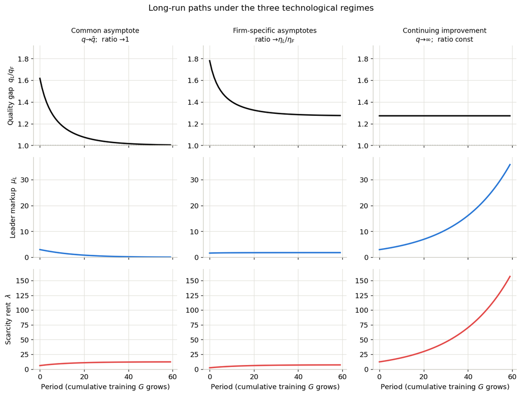

```
saved fig4_three_regimes.png
```

```python
metrics = [("Quality gap  $q_L/q_F$", "gap"),
           ("Leader markup  $\\mu_L$", "markup"),
           (r"Scarcity rent  $\lambda$", "lam")]
metric_colors = [INK, C_MARK, C_SCAR]

fig, axes = plt.subplots(3, 3, figsize=(11.5, 8.6), sharex=True)
for r, (mlabel, mkey) in enumerate(metrics):
    # shared y-limits within a row for comparability
    ymax = max(np.nanmax(p[mkey]) for p in paths) * 1.08
    ymin = min(np.nanmin(p[mkey]) for p in paths)
    ymin = min(ymin, 1.0) if mkey == "gap" else min(ymin, 0.0)
    for cix, p in enumerate(paths):
        ax = axes[r, cix]
        ax.plot(np.arange(Tt), p[mkey], color=metric_colors[r], lw=2.2)
        ax.set_ylim(ymin, ymax)
        if r == 0:
            ax.set_title(p["name"] + "\n" + p["sub"], fontsize=10.5, color=INK)
        if cix == 0:
            ax.set_ylabel(mlabel, fontsize=10.5)
        if r == 2:
            ax.set_xlabel("Period (cumulative training $G$ grows)")
        if mkey == "gap":
            ax.axhline(1.0, color=MUTED, ls=":", lw=1)

fig.suptitle("Long-run paths under the three technological regimes", fontsize=13, color=INK, y=1.0)
fig.tight_layout()
fig.savefig(FIGDIR / "fig4_three_regimes.png")
plt.show()
print("saved fig4_three_regimes.png")
```

## Notes, issues, and open questions

Collected here are the modeling choices, the places the numbers only partly back the prose, and a few things that might be worth the paper author's attention. None of these were "fixed" in the paper — this notebook does not touch it.

### Reuse notes (for the future web-demo port)

- Every formula lives in a small pure function: `v_schedule`, `allocate`, `surplus_split`, `cournot_decomposition`, `cournot_binding_threshold`, `vertical_duopoly_markup`, the three `q_*` regime laws, and `simulate_releases`. These map one-to-one to the `src/model/` files in the web-demo plan (`allocation.ts`, `cournot.ts`, `dynamics.ts`, `regimes.ts`, `demand.ts`).
- `allocate` solves the shadow price by 200-step bisection on `λ ∈ [0, max_m q_m·θ_max]`; with the piecewise-linear uniform-θ demand this is exact to ~1e-12. Port the bisection, not a closed form, since the active set changes with `K`.
- The simulation is seeded (`numpy.default_rng(seed)`); a TypeScript port should use a matching seeded PRNG (e.g. mulberry32) if it needs to reproduce identical runs for a fixtures oracle.
- Firm names are generic on purpose; keep them that way.

## 5. Machine-checkable fixtures for the web companion (`fixtures.json`)

The figures above are the paper's numerical illustration. This final section serves the *other* role the notebook plays in the companion project: it is the **test oracle** for the web app's TypeScript model core (`web/src/model/*.ts`). The plan's single most important architectural rule is that every equation lives exactly once in `src/model/`, and that the TypeScript is checked against an independent implementation — this one.

The last cell evaluates them at a handful of parameter combinations — a couple of `K` values for the allocation and shadow price, a WTA case that holds and one that doesn't, binding/slack/neutral Cournot cases, a few bargaining and `V_lead` combinations, and spot values from the regime, Bertrand, and subscription code — assembles everything into one nested dict, and writes it to `web/src/model/__tests__/fixtures.json`. The Vitest suite `fixtures.test.ts` imports that file and asserts the TypeScript reproduces every value to a relative tolerance of `1e-9`. Python floats serialize at full double precision by default, which is exactly what that tolerance needs.

**If you change a formula in either place, regenerate this file by re-running these cells and let the TypeScript test tell you whether the two implementations still agree.**

```python
import json, math
from pathlib import Path

# TS-signature ports (one-to-one with web/src/model/*.ts) for the oracle. These
# take fully explicit arguments and use math.* scalar ops so the arithmetic
# matches the TypeScript exactly; the figures above use the vectorized helpers.
# Where an earlier cell defined an equivalent, an assert cross-checks agreement.

# NORMALIZED preset (presets.ts), suffixed "_" to avoid clobbering earlier cells.
C_  = 1.0
K_  = 100.0
N_  = 300.0
TH_ = 10.0
FIRMS_ = [
    {"name": "Leader",     "q": 1.4, "a": 1.0, "b": 0.0},
    {"name": "Follower A", "q": 1.1, "a": 1.0, "b": 0.0},
    {"name": "Follower B", "q": 0.9, "a": 1.0, "b": 0.0},
]
BISECTION_ITERS = 200

# --- allocation.ts ---------------------------------------------------------
def v_schedule_ts(x, q, a, b, thetaMax, N):
    return q * thetaMax * (1 - (2 * x) / (a * N)) - b / a

def v_intercept(q, a, b, thetaMax):
    return q * thetaMax - b / a

def _x_of_lambda(lam, q, a, b, c, thetaMax, N):
    return max(0.0, ((a * N) / 2) * (1 - (c + lam + b / a) / (q * thetaMax)))

def allocate_ts(c, K, N, thetaMax, firms):
    total_at = lambda lam: sum(_x_of_lambda(lam, f["q"], f["a"], f["b"], c, thetaMax, N) for f in firms)
    lam = 0.0
    if total_at(0.0) > K:
        lo, hi = 0.0, max(v_intercept(f["q"], f["a"], f["b"], thetaMax) for f in firms)
        for _ in range(BISECTION_ITERS):
            mid = 0.5 * (lo + hi)
            if total_at(mid) > K: lo = mid
            else: hi = mid
        lam = 0.5 * (lo + hi)
    allocations = []
    for f in firms:
        x = _x_of_lambda(lam, f["q"], f["a"], f["b"], c, thetaMax, N)
        allocations.append({"name": f["name"], "x": x, "y": x / f["a"],
                            "v": v_schedule_ts(x, f["q"], f["a"], f["b"], thetaMax, N),
                            "active": x > 1e-9})
    return {"allocations": allocations, "lambda": lam, "capacityBinds": lam > 1e-9}

def wta_test(K, N, thetaMax, firms):
    intercepts = [v_intercept(f["q"], f["a"], f["b"], thetaMax) for f in firms]
    li = max(range(len(firms)), key=lambda i: intercepts[i])
    leader = firms[li]
    return {"isWTA": v_schedule_ts(K, leader["q"], leader["a"], leader["b"], thetaMax, N)
                     >= max(intercepts[i] for i in range(len(firms)) if i != li),
            "leader": leader["name"],
            "vLeaderAtK": v_schedule_ts(K, leader["q"], leader["a"], leader["b"], thetaMax, N),
            "bestFollowerV0": max(intercepts[i] for i in range(len(firms)) if i != li)}

# --- cournot.ts ------------------------------------------------------------
def linear_demand_from_vertical(Q, N, thetaMax):
    return {"A": Q * thetaMax, "B": (Q * thetaMax) / N}

def _cournot_output_at_cost(A, B, a, b, c, n):
    return (n * (A - b - a * c)) / (B * (n + 1))

def cournot_equilibrium(A, B, a, b, c, n, K):
    binding = K < a * _cournot_output_at_cost(A, B, a, b, c, n) - 1e-12
    if binding:
        P = A - (B * K) / a
        r = (A - b) / a - (B * (n + 1) * K) / (a * a * n)
        per_firm_markup = (B * K) / (a * n)
        lab_profit = (B * K * K) / (a * a * n)
    else:
        r = c
        kappa = b + a * c
        y_firm = (A - kappa) / (B * (n + 1))
        P = A - B * (n * y_firm)
        per_firm_markup = P - kappa
        lab_profit = n * per_firm_markup * y_firm
    physical, scarcity = b + a * c, a * (r - c)
    return {"P": P, "r": r, "physicalCost": physical, "scarcityRent": scarcity,
            "markup": P - physical - scarcity, "perFirmMarkup": per_firm_markup,
            "labProfitAggregate": lab_profit, "binding": binding}

# --- bargaining.ts ---------------------------------------------------------
def nash_bargain(vHat, vHatF, c, zeta):
    barVH = max(c, vHatF)
    ms = vHat - barVH
    negotiated = zeta * barVH + (1 - zeta) * vHat
    return {"negotiatedPrice": negotiated, "matchSurplus": ms, "barVH": barVH,
            "labRent": zeta * ms, "hyperscalerIncremental": (1 - zeta) * ms,
            "hyperscalerMargin": negotiated - c}

# --- dynamics.ts (vLead) ---------------------------------------------------
def v_lead(deltaPi, r, Lambda):
    denom = r + Lambda
    return math.inf if denom <= 0 else deltaPi / denom

# --- regimes.ts (four q(G) laws) ------------------------------------------
def q_common_asymptote(G, qBar, d, psi, beta):
    return qBar - d * math.pow(max(psi * G, 1e-12), -beta)
def q_firm_asymptote(G, qBar, d, eta, beta):
    return eta * qBar - d * math.pow(max(G, 1e-12), -beta)
def q_continuing_law(G, eta, beta):
    return eta * math.pow(max(G, 0), beta)
def q_continuing_additive_law(G, alpha, beta):
    return math.pow(max(G, 0), beta) + alpha

# --- demand.ts (bertrandDuopoly) -------------------------------------------
def bertrand_duopoly(QL, QF, kappaL, kappaF, thetaMax, iters=400):
    dQ = max(QL - QF, 1e-9)
    inv = 1 / dQ + 1 / QF
    PL, PF = kappaL + 0.5 * dQ * thetaMax, kappaF + 0.1
    for _ in range(iters):
        PLn = 0.5 * (dQ * thetaMax + PF + kappaL)
        PFn = (PLn / dQ + kappaF * inv) / (2 * inv)
        if abs(PLn - PL) < 1e-12 and abs(PFn - PF) < 1e-12:
            PL, PF = PLn, PFn; break
        PL, PF = PLn, PFn
    return {"PL": PL, "PF": PF, "muL": max(PL - kappaL, 0.0)}

# --- subscriptions.ts ------------------------------------------------------
def net_value(theta, prov, k):
    return theta * prov["quality"][k] - prov["rho"]
def best_net_value(theta, k, S, providers):
    return max([0.0] + [net_value(theta, providers[m], k) for m in S])
def portfolio_utility(theta, S, tasks, providers):
    return (sum(tasks[k]["count"] * best_net_value(theta, k, S, providers) for k in range(len(tasks)))
            - sum(providers[m]["phi"] for m in S))
def incremental_value(theta, j, S, tasks, providers):
    prov = providers[j]
    total = 0.0
    for k in range(len(tasks)):
        gain = net_value(theta, prov, k) - best_net_value(theta, k, S, providers)
        if gain > 0: total += tasks[k]["count"] * gain
    return total - prov.get("evalCost", 0.0)
def greedy_portfolio(theta, tasks, providers):
    S, in_s = [], [False] * len(providers)
    while True:
        best_j, best_net = -1, 0.0
        for j in range(len(providers)):
            if in_s[j]: continue
            net = incremental_value(theta, j, S, tasks, providers) - providers[j]["phi"]
            if net > best_net + 1e-12: best_net, best_j = net, j
        if best_j < 0: break
        S.append(best_j); in_s[best_j] = True
    return sorted(S)
def single_provider_subscribes(spot, rho, expected_outputs, phi):
    return (spot - rho) * expected_outputs >= phi

# Cross-check the TS-port allocator against this notebook's own `allocate`
# (the engine behind Figures 1 and 3) at the baseline, if it has been run.
if "allocate" in globals():
    _x_nb, _lam_nb = allocate(K_, [f["q"] for f in FIRMS_])
    _res_ts = allocate_ts(C_, K_, N_, TH_, FIRMS_)
    assert abs(_lam_nb - _res_ts["lambda"]) < 1e-9, "port disagrees with notebook allocate() on lambda"
    for _xn, _al in zip(_x_nb, _res_ts["allocations"]):
        assert abs(_xn - _al["x"]) < 1e-6, "port disagrees with notebook allocate() on x"
    print("cross-check OK: TS-port allocate_ts agrees with the notebook's allocate() at baseline")
print("fixture-generating functions defined.")
```

```
cross-check OK: TS-port allocate_ts agrees with the notebook's allocate() at baseline
fixture-generating functions defined.
```

```python
# Assemble every fixture into one nested dict and write fixtures.json.
# Python floats serialize at full double precision by default, which is what the
# 1e-9 Vitest tolerance needs. The web repo's copy is the authoritative oracle:
#   web/src/model/__tests__/fixtures.json
fixtures = {
    "meta": {
        "source": "notebook/llm-econ-model.ipynb (Python/numpy oracle)",
        "preset": "NORMALIZED",
        "note": "Independent Python re-implementation of src/model/*.ts; the "
                "Vitest oracle (fixtures.test.ts) asserts the TypeScript matches "
                "these to 1e-9.",
    },
    "params": {"c": C_, "K": K_, "N": N_, "thetaMax": TH_, "firms": FIRMS_},
}

# 1) Water-filling allocation: tight (K=40, Follower B drops out), baseline
#    (K=100), slack (K=450, lambda=0).
alloc_cases = []
for Kc in (40.0, 100.0, 450.0):
    res = allocate_ts(C_, Kc, N_, TH_, FIRMS_)
    alloc_cases.append({
        "c": C_, "K": Kc, "N": N_, "thetaMax": TH_,
        "firms": [{"q": f["q"], "a": f["a"], "b": f["b"]} for f in FIRMS_],
        "lambda": res["lambda"], "capacityBinds": res["capacityBinds"],
        "allocations": res["allocations"],
    })
fixtures["allocation"] = alloc_cases

# 2) WTA condition: holds at K=30, fails at K=100.
wta_cases = []
for Kc in (30.0, 100.0):
    res = wta_test(Kc, N_, TH_, FIRMS_)
    wta_cases.append({
        "K": Kc, "N": N_, "thetaMax": TH_,
        "firms": [{"q": f["q"], "a": f["a"], "b": f["b"]} for f in FIRMS_],
        **res,
    })
fixtures["wta"] = wta_cases

# 3) Cournot / App. D: leader-quality mapping A=q_L*theta_max, B=A/N. Binding
#    (n=3,K=100), capacity-neutrality (n=6,K=100 gives the same P), slack
#    (n=3,K=260), and the monopoly corner (n=1).
Q_REP = FIRMS_[0]["a"] * FIRMS_[0]["q"]
lin = linear_demand_from_vertical(Q_REP, N_, TH_)
A_, B_ = lin["A"], lin["B"]
cournot_cases = []
for n, Kc in [(3, 100.0), (6, 100.0), (3, 260.0), (1, 100.0)]:
    res = cournot_equilibrium(A_, B_, 1.0, 0.0, C_, n, Kc)
    cournot_cases.append({"A": A_, "B": B_, "a": 1.0, "b": 0.0, "c": C_, "n": n, "K": Kc, **res})
fixtures["cournot"] = cournot_cases

# 4) Nash bargaining: interior split, vHatF<c corner (barVH pins to c), zeta=1.
barg_cases = []
for vHat, vHatF, c, zeta in [(8.533, 3.0, 1.0, 0.5), (8.533, 0.5, 1.0, 0.3), (6.0, 4.0, 1.0, 1.0)]:
    barg_cases.append({"vHat": vHat, "vHatF": vHatF, "c": c, "zeta": zeta,
                       **nash_bargain(vHat, vHatF, c, zeta)})
fixtures["bargaining"] = barg_cases

# 5) V_lead = deltaPi / (r + Lambda).
fixtures["vLead"] = [
    {"deltaPi": dPi, "r": r, "Lambda": Lam, "V": v_lead(dPi, r, Lam)}
    for dPi, r, Lam in [(3.0, 0.05, 0.5), (10.0, 0.08, 0.4), (0.0, 0.05, 0.5)]
]

# 6) Regime q(G) laws (S6 defaults) — one spot value each.
fixtures["regimes"] = [
    {"regime": "common", "G": 10.0, "qBar": 1.6, "d": 0.55, "psi": 1.8, "beta": 0.4,
     "q": q_common_asymptote(10.0, 1.6, 0.55, 1.8, 0.4)},
    {"regime": "firm-specific", "G": 10.0, "qBar": 1.6, "d": 0.55, "eta": 1.27, "beta": 0.4,
     "q": q_firm_asymptote(10.0, 1.6, 0.55, 1.27, 0.4)},
    {"regime": "continuing", "G": 10.0, "eta": 1.4, "beta": 0.4,
     "q": q_continuing_law(10.0, 1.4, 0.4)},
    {"regime": "continuing-additive", "G": 10.0, "alpha": 0.27, "beta": 0.4,
     "q": q_continuing_additive_law(10.0, 0.27, 0.4)},
]

# 7) Bertrand duopoly spot (compute at physical cost, kappa = a*c).
bert = bertrand_duopoly(1.4, 1.1, 1.0 * C_, 1.0 * C_, TH_)
fixtures["bertrand"] = [
    {"QL": 1.4, "QF": 1.1, "kappaL": 1.0, "kappaF": 1.0, "thetaMax": TH_, **bert},
]

# 8) Subscriptions / multi-homing spot values (theta=6, 3 tasks, 3 providers).
SUB_THETA = 6.0
SUB_TASKS = [{"name": "Writing", "count": 8}, {"name": "Coding", "count": 6}, {"name": "Analysis", "count": 4}]
SUB_PROVIDERS = [
    {"name": "Leader", "phi": 20.0, "rho": 1.0, "a": 1.5, "quality": [1.4, 1.3, 1.5]},
    {"name": "Follower A", "phi": 8.0, "rho": 0.6, "a": 1.0, "quality": [1.1, 1.45, 1.2]},
    {"name": "Follower B", "phi": 5.0, "rho": 0.4, "a": 0.6, "quality": [0.9, 0.9, 0.95]},
]
fixtures["subscriptions"] = {
    "theta": SUB_THETA, "tasks": SUB_TASKS, "providers": SUB_PROVIDERS,
    "netValue_p0_t0": net_value(SUB_THETA, SUB_PROVIDERS[0], 0),
    "incrementalValue_p1_empty": incremental_value(SUB_THETA, 1, [], SUB_TASKS, SUB_PROVIDERS),
    "incrementalValue_p1_given0": incremental_value(SUB_THETA, 1, [0], SUB_TASKS, SUB_PROVIDERS),
    "portfolioUtility_all": portfolio_utility(SUB_THETA, [0, 1, 2], SUB_TASKS, SUB_PROVIDERS),
    "greedyPortfolio": greedy_portfolio(SUB_THETA, SUB_TASKS, SUB_PROVIDERS),
    "singleProviderSubscribes": single_provider_subscribes(9.333, 1.0, 5.0, 20.0),
}

OUT = Path("..") / "web" / "src" / "model" / "__tests__" / "fixtures.json"
OUT.parent.mkdir(parents=True, exist_ok=True)
OUT.write_text(json.dumps(fixtures, indent=2), encoding="utf-8")
print("Wrote", OUT.resolve())
print("  lambda@K=100        =", alloc_cases[1]["lambda"])
print("  P*(n=3,K=100)       =", cournot_cases[0]["P"], " P*(n=6,K=100) =", cournot_cases[1]["P"], "(neutrality)")
print("  greedy portfolio    =", fixtures["subscriptions"]["greedyPortfolio"])
```

```
Wrote C:\Apps\AI-Econ\web\src\model\__tests__\fixtures.json
  lambda@K=100        = 7.532981530343006
  P*(n=3,K=100)       = 9.333333333333332  P*(n=6,K=100) = 9.333333333333332 (neutrality)
  greedy portfolio    = [1]
```